[figure not shown]

# Проект: Анализ резюме из HeadHunter

```python
import pandas as pd
import numpy as np
import matplotlib.pyplot as plt
import seaborn as sns
import plotly.express as px
```

# Исследование структуры данных

1. Прочитайте данные с помощью библиотеки Pandas. Совет: перед чтением обратите внимание на разделитель внутри файла.

```python
# ваш код здесь

database = pd.read_csv("data/dst-3.0_16_1_hh_database.csv", sep=";")
```

2. Выведите несколько первых (последних) строк таблицы, чтобы убедиться в том, что ваши данные не повреждены. Ознакомьтесь с признаками и их структурой.

```python
# ваш код здесь

database.head()
```

|  | Пол, возраст | ЗП | Ищет работу на должность: | Город, переезд, командировки | Занятость | График | Опыт работы | Последнее/нынешнее место работы | Последняя/нынешняя должность | Образование и ВУЗ | Обновление резюме | Авто |
| --- | --- | --- | --- | --- | --- | --- | --- | --- | --- | --- | --- | --- |
| 0 | Мужчина , 39 лет , родился 27 ноября 1979 | 29000 руб. | Системный администратор | Советск (Калининградская область) , не готов к... | частичная занятость, проектная работа, полная ... | гибкий график, полный день, сменный график, ва... | Опыт работы 16 лет 10 месяцев Август 2010 — п... | МАОУ "СОШ № 1 г.Немана" | Системный администратор | Неоконченное высшее образование 2000 Балтийск... | 16.04.2019 15:59 | Имеется собственный автомобиль |
| 1 | Мужчина , 60 лет , родился 20 марта 1959 | 40000 руб. | Технический писатель | Королев , не готов к переезду , готов к редким... | частичная занятость, проектная работа, полная ... | гибкий график, полный день, сменный график, уд... | Опыт работы 19 лет 5 месяцев Январь 2000 — по... | Временный трудовой коллектив | Менеджер проекта, Аналитик, Технический писатель | Высшее образование 1981 Военно-космическая ак... | 12.04.2019 08:42 | Не указано |
| 2 | Женщина , 36 лет , родилась 12 августа 1982 | 20000 руб. | Оператор | Тверь , не готова к переезду , не готова к ком... | полная занятость | полный день | Опыт работы 10 лет 3 месяца Октябрь 2004 — Де... | ПАО Сбербанк | Кассир-операционист | Среднее специальное образование 2002 Профессио... | 16.04.2019 08:35 | Не указано |
| 3 | Мужчина , 38 лет , родился 25 июня 1980 | 100000 руб. | Веб-разработчик (HTML / CSS / JS / PHP / базы ... | Саратов , не готов к переезду , готов к редким... | частичная занятость, проектная работа, полная ... | гибкий график, удаленная работа | Опыт работы 18 лет 9 месяцев Август 2017 — Ап... | OpenSoft | Инженер-программист | Высшее образование 2002 Саратовский государст... | 08.04.2019 14:23 | Не указано |
| 4 | Женщина , 26 лет , родилась 3 марта 1993 | 140000 руб. | Региональный менеджер по продажам | Москва , не готова к переезду , готова к коман... | полная занятость | полный день | Опыт работы 5 лет 7 месяцев Региональный мене... | Мармелад | Менеджер по продажам | Высшее образование 2015 Кгу Психологии и педаг... | 22.04.2019 10:32 | Не указано |

3. Выведите основную информацию о числе непустых значений в столбцах и их типах в таблице.

```python
# ваш код здесь

database.info()
```

```
<class 'pandas.core.frame.DataFrame'>
RangeIndex: 44744 entries, 0 to 44743
Data columns (total 12 columns):
 #   Column                           Non-Null Count  Dtype
---  ------                           --------------  -----
 0   Пол, возраст                     44744 non-null  object
 1   ЗП                               44744 non-null  object
 2   Ищет работу на должность:        44744 non-null  object
 3   Город, переезд, командировки     44744 non-null  object
 4   Занятость                        44744 non-null  object
 5   График                           44744 non-null  object
 6   Опыт работы                      44576 non-null  object
 7   Последнее/нынешнее место работы  44743 non-null  object
 8   Последняя/нынешняя должность     44742 non-null  object
 9   Образование и ВУЗ                44744 non-null  object
 10  Обновление резюме                44744 non-null  object
 11  Авто                             44744 non-null  object
dtypes: object(12)
memory usage: 4.1+ MB
```

4. Обратите внимание на информацию о числе непустых значений.

```python
# ваш код здесь

database.isnull().sum().to_frame()
```

|  | 0 |
| --- | --- |
| Пол, возраст | 0 |
| ЗП | 0 |
| Ищет работу на должность: | 0 |
| Город, переезд, командировки | 0 |
| Занятость | 0 |
| График | 0 |
| Опыт работы | 168 |
| Последнее/нынешнее место работы | 1 |
| Последняя/нынешняя должность | 2 |
| Образование и ВУЗ | 0 |
| Обновление резюме | 0 |
| Авто | 0 |

5. Выведите основную статистическую информацию о столбцах.

```python
# ваш код здесь

database.describe()
```

|  | Пол, возраст | ЗП | Ищет работу на должность: | Город, переезд, командировки | Занятость | График | Опыт работы | Последнее/нынешнее место работы | Последняя/нынешняя должность | Образование и ВУЗ | Обновление резюме | Авто |
| --- | --- | --- | --- | --- | --- | --- | --- | --- | --- | --- | --- | --- |
| count | 44744 | 44744 | 44744 | 44744 | 44744 | 44744 | 44576 | 44743 | 44742 | 44744 | 44744 | 44744 |
| unique | 16003 | 690 | 14929 | 10063 | 38 | 47 | 44413 | 30214 | 16927 | 40148 | 18838 | 2 |
| top | Мужчина , 32 года , родился 17 сентября 1986 | 50000 руб. | Системный администратор | Москва , не готов к переезду , не готов к кома... | полная занятость | полный день | Опыт работы 10 лет 8 месяцев Апрель 2018 — по... | Индивидуальное предпринимательство / частная п... | Системный администратор | Высшее образование 1987 Военный инженерный Кра... | 07.05.2019 09:50 | Не указано |
| freq | 18 | 4064 | 3099 | 1261 | 30026 | 22727 | 3 | 935 | 2062 | 4 | 25 | 32268 |

# Преобразование данных

1. Начнем с простого - с признака **"Образование и ВУЗ"**. Его текущий формат это: **<Уровень образования год выпуска ВУЗ специальность...>**. Например:
- Высшее образование 2016 Московский авиационный институт (национальный исследовательский университет)...
- Неоконченное высшее образование 2000 Балтийская государственная академия рыбопромыслового флота…

Нас будет интересовать только уровень образования.

Создайте с помощью функции-преобразования новый признак **"Образование"**, который должен иметь 4 категории: "высшее", "неоконченное высшее", "среднее специальное" и "среднее".

Выполните преобразование, ответьте на контрольные вопросы и удалите признак "Образование и ВУЗ".

Совет: обратите внимание на структуру текста в столбце **"Образование и ВУЗ"**. Гарантируется, что текущий уровень образования соискателя всегда находится в первых 2ух слов и начинается с заглавной буквы. Воспользуйтесь этим.

*Совет: проверяйте полученные категории, например, с помощью метода unique()*

```python
# ваш код здесь

database["Образование"] = database["Образование и ВУЗ"].apply(
    lambda x: str(x).split("образование")[0].lower().strip()
)

del database["Образование и ВУЗ"]

database["Образование"].unique()
```

```
array(['неоконченное высшее', 'высшее', 'среднее специальное', 'среднее'],
      dtype=object)
```

```python
database["Образование"].value_counts()
```

```
Образование
высшее                 33863
среднее специальное     5765
неоконченное высшее     4557
среднее                  559
Name: count, dtype: int64
```

2. Теперь нас интересует столбец **"Пол, возраст"**. Сейчас он представлен в формате **<Пол , возраст , дата рождения >**. Например:
- Мужчина , 39 лет , родился 27 ноября 1979
- Женщина , 21 год , родилась 13 января 2000

Как вы понимаете, нам необходимо выделить каждый параметр в отдельный столбец.

Создайте два новых признака **"Пол"** и **"Возраст"**. При этом важно учесть:

- Признак пола должен иметь 2 уникальных строковых значения: 'М' - мужчина, 'Ж' - женщина.
- Признак возраста должен быть представлен целыми числами.

Выполните преобразование, ответьте на контрольные вопросы и удалите признак **"Пол, возраст"** из таблицы.

*Совет: обратите внимание на структуру текста в столбце, в части на то, как разделены параметры пола, возраста и даты рождения между собой - символом ' , '. Гарантируется, что структура одинакова для всех строк в таблице. Вы можете воспользоваться этим.*

```python
# ваш код здесь

database["Пол"] = (
    database["Пол, возраст"]
    .apply(lambda x: str(x).split(",")[0].lower().strip())
    .replace({"мужчина": "М", "женщина": "Ж"})
)

database["Возраст"] = database["Пол, возраст"].apply(
    lambda x: str(x).split(" ")[3].strip()
).astype(int)

del database["Пол, возраст"]
```

```python
database["Пол"].value_counts(normalize=True) * 100
```

```
Пол
М    80.929287
Ж    19.070713
Name: proportion, dtype: float64
```

```python
round(database["Возраст"].astype(int).mean(), 2)
```

```
32.2
```

3. Следующим этапом преобразуем признак **"Опыт работы"**. Его текущий формат - это: **<Опыт работы: n лет m месяцев, периоды работы в различных компаниях…>**.

Из столбца нам необходимо выделить общий опыт работы соискателя в месяцах, новый признак назовем "Опыт работы (месяц)"

Для начала обсудим условия решения задачи:

- Во-первых, в данном признаке есть пропуски. Условимся, что если мы встречаем пропуск, оставляем его как есть (функция-преобразование возвращает NaN)
- Во-вторых, в данном признаке есть скрытые пропуски. Для некоторых соискателей в столбце стоит значения "Не указано". Их тоже обозначим как NaN (функция-преобразование возвращает NaN)
- В-третьих, нас не интересует информация, которая описывается после указания опыта работы (периоды работы в различных компаниях)
- В-четвертых, у нас есть проблема: опыт работы может быть представлен только в годах или только месяцах. Например, можно встретить следующие варианты:
  - Опыт работы 3 года 2 месяца…
  - Опыт работы 4 года…
  - Опыт работы 11 месяцев…
  - Учитывайте эту особенность в вашем коде

Учитывайте эту особенность в вашем коде

В результате преобразования у вас должен получиться столбец, содержащий информацию о том, сколько месяцев проработал соискатель. Выполните преобразование, ответьте на контрольные вопросы и удалите столбец **"Опыт работы"** из таблицы.

```python
# ваш код здесь

def get_experience(arg):

    month_keys = ["месяц", "месяца", "месяцев"]
    year_key = ["год", "года", "лет"]

    year = 0
    month = 0

    if pd.isnull(arg) or arg == "Не указано":
        return np.nan

    else:
        arg_split = arg.split("  ")[0].split(" ")[2:]

        for i in range(len(arg_split)):

            if arg_split[i] in month_keys:
                month = arg_split[i - 1]

            if arg_split[i] in year_key:
                year = arg_split[i - 1]

        return int(year) * 12 + int(month)


database["Опыт работы (месяц)"] = database["Опыт работы"].apply(get_experience)

del database["Опыт работы"]
```

```python
database["Опыт работы (месяц)"].median()
```

```
100.0
```

4. Хорошо идем! Следующий на очереди признак "Город, переезд, командировки". Информация в нем представлена в следующем виде: **<Город , (метро) , готовность к переезду (города для переезда) , готовность к командировкам>**. В скобках указаны необязательные параметры строки. Например, можно встретить следующие варианты:
- Москва , не готов к переезду , готов к командировкам
- Москва , м. Беломорская , не готов к переезду, не готов к командировкам
- Воронеж , готов к переезду (Сочи, Москва, Санкт-Петербург) , готов к командировкам

Создадим отдельные признаки **"Город"**, **"Готовность к переезду"**, **"Готовность к командировкам"**. При этом важно учесть:

- Признак **"Город"** должен содержать только 4 категории: "Москва", "Санкт-Петербург" и "город-миллионник" (их список ниже), остальные обозначьте как "другие".

  Список городов-миллионников:

  `million_cities = ['Новосибирск', 'Екатеринбург','Нижний Новгород','Казань', 'Челябинск','Омск', 'Самара', 'Ростов-на-Дону', 'Уфа', 'Красноярск', 'Пермь', 'Воронеж','Волгоград']`

  Инфорация о метро, рядом с которым проживает соискатель нас не интересует.
- Признак **"Готовность к переезду"** должен иметь два возможных варианта: True или False. Обратите внимание, что возможны несколько вариантов описания готовности к переезду в признаке "Город, переезд, командировки". Например:
  - … , готов к переезду , …
  - … , не готова к переезду , …
  - … , готова к переезду (Москва, Санкт-Петербург, Ростов-на-Дону)
  - … , хочу переехать (США) , …

  Нас интересует только сам факт возможности или желания переезда.
- Признак **"Готовность к командировкам"** должен иметь два возможных варианта: True или False. Обратите внимание, что возможны несколько вариантов описания готовности к командировкам в признаке "Город, переезд, командировки". Например:
  - … , готов к командировкам , …
  - … , готова к редким командировкам , …
  - … , не готов к командировкам , …

  Нас интересует только сам факт готовности к командировке.

  Еще один важный факт: при выгрузки данных у некоторых соискателей "потерялась" информация о готовности к командировкам. Давайте по умолчанию будем считать, что такие соискатели не готовы к командировкам.

Выполните преобразования и удалите столбец **"Город, переезд, командировки"** из таблицы.

*Совет: обратите внимание на то, что структура текста может меняться в зависимости от указания ближайшего метро. Учите это, если будете использовать порядок слов в своей программе.*

```python
million_cities = [
    "Новосибирск",
    "Екатеринбург",
    "Нижний Новгород",
    "Казань",
    "Челябинск",
    "Омск",
    "Самара",
    "Ростов-на-Дону",
    "Уфа",
    "Красноярск",
    "Пермь",
    "Воронеж",
    "Волгоград",
]
```

```python
# ваш код здесь

database["Город"] = database["Город, переезд, командировки"].apply(
    lambda x: (
        x.split(" ,")[0].strip()
        if x.split(" ,")[0].strip() in ["Москва", "Санкт-Петербург"]
        else (
            "город-милионник"
            if x.split(" ,")[0].strip() in million_cities
            else "другие"
        )
    )
)


database["Готовность к переезду"] = database["Город, переезд, командировки"].apply(
    lambda x: (
        False
        if "не готов к переезду" in x
        or "не готова к переезду" in x
        or "не хочу переехать" in x
        or pd.isnull(x)
        else True
    )
)

database["Готовность к командировкам"] = database["Город, переезд, командировки"].apply(
    lambda x: (
        False
        if "не готов к командировкам" in x
        or "не готова к командировкам" in x
        or pd.isnull(x)
        else True
    )
)

del database["Город, переезд, командировки"]
```

```python
database["Город"].value_counts(normalize=True) * 100
```

```
Город
Москва             37.146880
другие             35.432684
город-милионник    16.386555
Санкт-Петербург    11.033882
Name: proportion, dtype: float64
```

```python
int(
    database[
        (database["Готовность к командировкам"]) & (database["Готовность к переезду"])
    ].shape[0]
    / database.shape[0]
    * 100
)
```

```
32
```

5. Рассмотрим поближе признаки **"Занятость"** и **"График"**. Сейчас признаки представляют собой набор категорий желаемой занятости (полная занятость, частичная занятость, проектная работа, волонтерство, стажировка) и желаемого графика работы (полный день, сменный график, гибкий график, удаленная работа, вахтовый метод).

На сайте hh.ru соискатель может указывать различные комбинации данных категорий, например:

- полная занятость, частичная занятость
- частичная занятость, проектная работа, волонтерство
- полный день, удаленная работа
- вахтовый метод, гибкий график, удаленная работа, полная занятость

Такой вариант признаков имеет множество различных комбинаций, а значит множество уникальных значений, что мешает анализу. Нужно это исправить!

Давайте создадим признаки-мигалки для каждой категории: если категория присутствует в списке желаемых соискателем, то в столбце на месте строки рассматриваемого соискателя ставится True, иначе - False.

Такой метод преобразования категориальных признаков называется One Hot Encoding и его схема представлена на рисунке ниже:

[figure not shown]

Выполните данное преобразование для признаков "Занятость" и "График", ответьте на контрольные вопросы, после чего удалите их из таблицы

```python
# ваш код здесь
one_hot_employment = database["Занятость"].str.get_dummies(sep=", ").astype(bool)
one_hot_schedule = database["График"].str.get_dummies(sep=", ").astype(bool)

database = pd.concat([database, one_hot_employment, one_hot_schedule], axis=1)

del database["Занятость"], database["График"]
```

```python
database[database["проектная работа"] & database["волонтерство"]].shape[0]
```

```
436
```

```python
database[database["вахтовый метод"] & database["гибкий график"]].shape[0]
```

```
2311
```

6. (2 балла) Наконец, мы добрались до самого главного и самого важного - признака заработной платы **"ЗП"**.

В чем наша беда? В том, что помимо желаемой заработной платы соискатель указывает валюту, в которой он бы хотел ее получать, например:

- 30000 руб.
- 50000 грн.
- 550 USD

Нам бы хотелось видеть заработную плату в единой валюте, например, в рублях. Возникает вопрос, а где взять курс валют по отношению к рублю?

На самом деле язык Python имеет в арсенале огромное количество возможностей получения данной информации, от обращения к API Центробанка, до использования специальных библиотек, например pycbrf. Однако, это не тема нашего проекта.

Поэтому мы пойдем в лоб: обратимся к специальным интернет-ресурсам для получения данных о курсе в виде текстовых файлов. Например, MDF.RU, данный ресурс позволяет удобно экспортировать данные о курсах различных валют и акций за указанные периоды в виде csv файлов. Мы уже сделали выгрузку курсов валют, которые встречаются в наших данных за период с 29.12.2017 по 05.12.2019. Скачать ее вы можете **на платформе**

Создайте новый DataFrame из полученного файла. В полученной таблице нас будут интересовать столбцы:

- "currency" - наименование валюты в ISO кодировке,
- "date" - дата,
- "proportion" - пропорция,
- "close" - цена закрытия (последний зафиксированный курс валюты на указанный день).

Перед вами таблица соответствия наименований иностранных валют в наших данных и их общепринятых сокращений, которые представлены в нашем файле с курсами валют. Пропорция - это число, за сколько единиц валюты указан курс в таблице с курсами. Например, для казахстанского тенге курс на 20.08.2019 составляет 17.197 руб. за 100 тенге, тогда итоговый курс равен - 17.197 / 100 = 0.17197 руб за 1 тенге. Воспользуйтесь этой информацией в ваших преобразованиях.

[figure not shown]

Осталось только понять, откуда брать дату, по которой определяется курс? А вот же она - в признаке **"Обновление резюме"**, в нем содержится дата и время, когда соискатель выложил текущий вариант своего резюме. Нас интересует только дата, по ней бы и будем сопоставлять курсы валют.

Теперь у нас есть вся необходимая информация для того, чтобы создать признак "ЗП (руб)" - заработная плата в рублях.

После ответа на контрольные вопросы удалите исходный столбец заработной платы "ЗП" и все промежуточные столбцы, если вы их создавали.

Итак, давайте обсудим возможный алгоритм преобразования:

1. Перевести признак "Обновление резюме" из таблицы с резюме в формат datetime и достать из него дату. В тот же формат привести признак "date" из таблицы с валютами.
2. Выделить из столбца "ЗП" сумму желаемой заработной платы и наименование валюты, в которой она исчисляется. Наименование валюты перевести в стандарт ISO согласно с таблицей выше.
3. Присоединить к таблице с резюме таблицу с курсами по столбцам с датой и названием валюты (подумайте, какой тип объединения надо выбрать, чтобы в таблице с резюме сохранились данные о заработной плате, изначально представленной в рублях). Значение close для рубля заполнить единицей 1 (курс рубля самого к себе)
4. Умножить сумму желаемой заработной платы на присоединенный курс валюты (close) и разделить на пропорцию (обратите внимание на пропуски после объединения в этих столбцах), результат занести в новый столбец "ЗП (руб)".

```python
# ваш код здесь

exchange_rates = pd.read_csv("data/ExchangeRates.csv")

currency_dict = {
    "грн": "UAH",
    "USD": "USD",
    "EUR": "EUR",
    "белруб": "BYN",
    "KGS": "KGS",
    "сум": "UZS",
    "AZN": "AZH",
    "KZT": "KZT",
}

# 1. Обновить признак "Обновление резюме" из таблицы с резюме, переведя его в формат datetime и выделив из него дату.
# В тот же формат привести признак date из таблицы с валютами.
exchange_rates["date"] = pd.to_datetime(exchange_rates["date"], dayfirst=True).dt.date
database["Обновление резюме"] = pd.to_datetime(
    database["Обновление резюме"], dayfirst=True
).dt.date

# 2. Выделить из столбца «ЗП» сумму желаемой заработной платы и наименование валюты, в которой она исчисляется
database[["ЗП (сум)", "ЗП (валюта)"]] = database["ЗП"].str.split(" ", expand=True)
database["ЗП (валюта)"] = (
    database["ЗП (валюта)"].str.replace(".", "", regex=False).str.replace(" ", "")
)
database["ЗП (валюта)"] = database["ЗП (валюта)"].replace(currency_dict)

# 3. Присоединить к таблице с резюме таблицу с курсами по столбцам с датой и названием валюты
# Значение close для рубля заполнить единицей 1 (курс рубля самого к себе).

database = pd.merge(
    database,
    exchange_rates,
    how="left",
    right_on=["date", "currency"],
    left_on=["Обновление резюме", "ЗП (валюта)"],
)

database.loc[database["ЗП (валюта)"] == "руб", "close"] = 1
database.loc[database["ЗП (валюта)"] == "руб", "proportion"] = 1

database["ЗП (руб)"] = database["ЗП (сум)"].astype(float) * database["close"] / database["proportion"]

# Удалите исходный столбец заработной платы «ЗП» и все промежуточные столбцы, если вы их создавали.
del database["ЗП (валюта)"], database["ЗП (сум)"], database["ЗП"],
```

```python
int(database["ЗП (руб)"].median() / 1000)
```

```
59
```

```python
database.drop(
    columns=[
        "currency",
        "per",
        "date",
        "time",
        "close",
        "vol",
        "proportion",
    ],
    inplace=True,
)
```

```python
database.info()
```

```
<class 'pandas.core.frame.DataFrame'>
RangeIndex: 44744 entries, 0 to 44743
Data columns (total 23 columns):
 #   Column                           Non-Null Count  Dtype
---  ------                           --------------  -----
 0   Ищет работу на должность:        44744 non-null  object
 1   Последнее/нынешнее место работы  44743 non-null  object
 2   Последняя/нынешняя должность     44742 non-null  object
 3   Обновление резюме                44744 non-null  object
 4   Авто                             44744 non-null  object
 5   Образование                      44744 non-null  object
 6   Пол                              44744 non-null  object
 7   Возраст                          44744 non-null  int32
 8   Опыт работы (месяц)              44574 non-null  float64
 9   Город                            44744 non-null  object
 10  Готовность к переезду            44744 non-null  bool
 11  Готовность к командировкам       44744 non-null  bool
 12  волонтерство                     44744 non-null  bool
 13  полная занятость                 44744 non-null  bool
 14  проектная работа                 44744 non-null  bool
 15  стажировка                       44744 non-null  bool
 16  частичная занятость              44744 non-null  bool
 17  вахтовый метод                   44744 non-null  bool
 18  гибкий график                    44744 non-null  bool
 19  полный день                      44744 non-null  bool
 20  сменный график                   44744 non-null  bool
 21  удаленная работа                 44744 non-null  bool
 22  ЗП (руб)                         44741 non-null  float64
dtypes: bool(12), float64(2), int32(1), object(8)
memory usage: 4.1+ MB
```

# Исследование зависимостей в данных

1. Постройте распределение признака **"Возраст"**. Опишите распределение, отвечая на следующие вопросы: чему равна мода распределения, каковы предельные значения признака, в каком примерном интервале находится возраст большинства соискателей? Есть ли аномалии для признака возраста, какие значения вы бы причислили к их числу?

*Совет: постройте гистограмму и коробчатую диаграмму рядом.*

```python
import plotly.graph_objects as go
from plotly.subplots import make_subplots
```

```python
# ваш код здесь

# Создаем общий график с двумя чартами
fig = make_subplots(
    rows=2,
    cols=1,
    shared_xaxes=False,
    vertical_spacing=0.2,
    subplot_titles=("Гистограмма", "Коробчатая диаграмма"),
)

# Добавляем гистограмму
fig.add_trace(
    go.Histogram(x=database["Возраст"], marker_color="blue", name="Гистограмма"),
    row=1,
    col=1,
)

# Добавляем коробчатую диаграмму
fig.add_trace(
    go.Box(x=database["Возраст"], marker_color="orange", name="Boxplot"), row=2, col=1
)

# Настраиваем оси и заголовки
fig.update_layout(
    height=700,
    title_text="Анализ возраста: Гистограмма и Boxplot",
    xaxis=dict(title="Возраст"),
    yaxis=dict(title="Частота"),
    xaxis2=dict(title="Возраст"),
)

fig.show()
```

[output not shown]

ваши выводы по графику здесь

- мода распределения равна 30
- предельные значения: min = 14, max = 100
- возраст большинства соискателей находится в интервале 27-36 лет
- аномальным можно считать возраст 100 лет, согласно коробчатой диаграмме. Возраст от 50 лет включительно, который тоже туда попал - норма возраста для поиска работы
2. Постройте распределение признака **"Опыт работы (месяц)"**. Опишите данное распределение, отвечая на следующие вопросы: чему равна мода распределения, каковы предельные значения признака, в каком примерном интервале находится опыт работы большинства соискателей? Есть ли аномалии для признака опыта работы, какие значения вы бы причислили к их числу?

*Совет: постройте гистограмму и коробчатую диаграмму рядом.*

```python
# ваш код здесь

# Создаем общий график с двумя чартами
fig = make_subplots(
    rows=2,
    cols=1,
    shared_xaxes=False,
    vertical_spacing=0.2,
    subplot_titles=("Гистограмма", "Коробчатая диаграмма"),
)

# Добавляем гистограмму
fig.add_trace(
    go.Histogram(x=database["Опыт работы (месяц)"], marker_color="blue", name="Гистограмма"),
    row=1,
    col=1,
)

# Добавляем коробчатую диаграмму
fig.add_trace(
    go.Box(x=database["Опыт работы (месяц)"], marker_color="orange", name="Boxplot"), row=2, col=1
)

# Настраиваем оси и заголовки
fig.update_layout(
    height=700,  # Общая высота графика
    title_text="Анализ опыта работы: Гистограмма и Boxplot",
    xaxis=dict(title="Опыт работы (месяц)"),
    yaxis=dict(title="Частота"),
    xaxis2=dict(title="Опыт работы (месяц)"),
)

fig.show()
```

[output not shown]

ваши выводы здесь

- мода распределения 80-84 месяцев
- медианный опыт 100 месяцев
- большинство соискателей имеют опыт работы в интервале от 67 до 154 месяцев
- аномальным выглядит опыт работы 1188 месяцев (99 лет)
3. Постройте распределение признака **"ЗП (руб)"**. Опишите данное распределение, отвечая на следующие вопросы: каковы предельные значения признака, в каком примерном интервале находится заработная плата большинства соискателей? Есть ли аномалии для признака возраста? Обратите внимание на гигантские размеры желаемой заработной платы.

*Совет: постройте гистограмму и коробчатую диаграмму рядом.*

```python
# ваш код здесь

# Создаем общий график с двумя чартами
fig = make_subplots(
    rows=2,
    cols=1,
    shared_xaxes=False,
    vertical_spacing=0.2,
    subplot_titles=("Гистограмма", "Коробчатая диаграмма"),
)

# Добавляем гистограмму
fig.add_trace(
    go.Histogram(x=database["ЗП (руб)"], marker_color="blue", name="Гистограмма"),
    row=1,
    col=1,
)

# Добавляем коробчатую диаграмму
fig.add_trace(
    go.Box(x=database["ЗП (руб)"], marker_color="orange", name="Boxplot"), row=2, col=1
)

# Настраиваем оси и заголовки
fig.update_layout(
    height=700,  # Общая высота графика
    title_text="Анализ опыта работы: Гистограмма и Boxplot",
    xaxis=dict(title="ЗП (руб)"),
    yaxis=dict(title="Частота"),
    xaxis2=dict(title="ЗП (руб)"),
)

fig.show()
```

[output not shown]

ваши выводы здесь

- предельные значения признака: min - 1 руб, max = 24.30488М руб
- большинство соискателей расчитывают на зп в интервале от 37к до 95к руб
- аномальными выглядят значения более 7 млн рублей, а также менее 10к руб. Как по мне, такие данные подлежат доп исследованию
4. Постройте диаграмму, которая показывает зависимость **медианной** желаемой заработной платы (**"ЗП (руб)"**) от уровня образования (**"Образование"**). Используйте для диаграммы данные о резюме, где желаемая заработная плата меньше 1 млн рублей.

*Сделайте выводы по представленной диаграмме: для каких уровней образования наблюдаются наибольшие и наименьшие уровни желаемой заработной платы? Как вы считаете, важен ли признак уровня образования при прогнозировании заработной платы?*

```python
# ваш код здесь

fig = px.bar(
    database[database["ЗП (руб)"] < 10**6]
    .groupby("Образование")["ЗП (руб)"]
    .median()
    .reset_index(),
    x="Образование",
    y ='ЗП (руб)',
    title="Медианная зарплата по уровню образования",
    labels={
        "ЗП (руб)": "Медианная зарплата (руб)",
        "Образование": "Уровень образования",
    },
    text="ЗП (руб)",
)

fig.update_traces(texttemplate="%{text:.2f}", textposition="outside")
fig.update_layout(
    xaxis_tickangle=-45,
    yaxis_title="Медианная зарплата (руб)",
    xaxis_title="Уровень образования",
    height=600,
    bargap=0.2,
)
fig.show()
```

[output not shown]

ваши выводы здесь

- наибольшие уровни зп для высшего и неоконченного высшего образования, наименьшие для среднего и среднего специального
- да, важен
5. Постройте диаграмму, которая показывает распределение желаемой заработной платы (**"ЗП (руб)"**) в зависимости от города (**"Город"**). Используйте для диаграммы данные о резюме, где желая заработная плата меньше 1 млн рублей.

*Сделайте выводы по полученной диаграмме: как соотносятся медианные уровни желаемой заработной платы и их размах в городах? Как вы считаете, важен ли признак города при прогнозировании заработной платы?*

```python
# ваш код здесь

fig = px.box(
    database[database["ЗП (руб)"] < 10**6],
    x="Город",
    y="ЗП (руб)",
    title="Распределение желаемой заработной платы (руб.)",
    labels={
        "ЗП (руб)": "Зарплата (руб)",
        "Город": "Город",
    },
)

fig.update_layout(
    xaxis_tickangle=-45,
    yaxis_title="Зарплата (руб)",
    xaxis_title="Город",
    height=600,
    bargap=0.2,
)
fig.show()
```

[output not shown]

ваши выводы здесь

- наибольшая медианная зарплата наблюдается в Москве, наименьшая в городах милионниках и других
- наибольший размах также в Москве, наименьший также в городах миллионниках и других
- признак города действительно важен, потому что имеются значительные отклонения в данных в Москве и Санкт-Перебурге
6. Постройте **многоуровневую столбчатую диаграмму**, которая показывает зависимость медианной заработной платы (**"ЗП (руб)"**) от признаков **"Готовность к переезду"** и **"Готовность к командировкам"**. Проанализируйте график, сравнив уровень заработной платы в категориях.

```python
# ваш код здесь

fig = px.bar(
    database.groupby(["Готовность к переезду", "Готовность к командировкам"], as_index=False)[
        "ЗП (руб)"
    ].median(),
    x="Готовность к переезду",
    y="ЗП (руб)",
    color="Готовность к командировкам",
    barmode="group",
    title="Зависимость медианной ЗП от готовности к переезду и командировкам",
    labels={
        "ЗП (руб)": "Медианная ЗП (руб)",
        "Готовность к переезду": "Готовность к переезду",
    },
)

fig.show()
```

[output not shown]

ваши выводы здесь

- оба признака влияют на ожидаепмую ЗП, однако готовность к командировкам несколько больше (ожидается бОльшая ЗП). Данный тип диаграммы не совсем подхолдит для удобной визуализации зависимости
7. Постройте сводную таблицу, иллюстрирующую зависимость **медианной** желаемой заработной платы от возраста (**"Возраст"**) и образования (**"Образование"**). На полученной сводной таблице постройте **тепловую карту**. Проанализируйте тепловую карту, сравнив показатели внутри групп.

```python
pivot_table = database.pivot_table(
    values="ЗП (руб)",
    index="Возраст",
    columns="Образование",
    aggfunc="median"
)

# Построение тепловой карты
fig = px.imshow(
    pivot_table,
    labels={"color": "Медианная ЗП (руб)"},
    x=pivot_table.columns,
    y=pivot_table.index,
    color_continuous_scale="Viridis",
    title="Тепловая карта зависимости медианной ЗП от возраста и образования",
    height=900
)

fig.show()
```

[output not shown]

ваши выводы здесь

- наиболее высокая ожидаемая зп в возрасте 35-50 лет
- наиболее высокая ожидаемая зп у людей с высшим образованием, наиболее низкая со средним специальным и средним образованием
8. Постройте **диаграмму рассеяния**, показывающую зависимость опыта работы (**"Опыт работы (месяц)"**) от возраста (**"Возраст"**). Опыт работы переведите из месяцев в года, чтобы признаки были в едином масштабе. Постройте на графике дополнительно прямую, проходящую через точки (0, 0) и (100, 100). Данная прямая соответствует значениям, когда опыт работы равен возрасту человека. Точки, лежащие на этой прямой и выше нее - аномалии в наших данных (опыт работы больше либо равен возрасту соискателя)

```python
# ваш код здесь

# Преобразование опыта работы из месяцев в годы
database["Опыт работы (год)"] = database["Опыт работы (месяц)"] / 12

# Построение диаграммы рассеяния
fig = px.scatter(
    database,
    x="Возраст",
    y="Опыт работы (год)",
    title="Диаграмма рассеяния: опыт работы vs возраст",
    labels={"Возраст": "Возраст (лет)", "Опыт работы (год)": "Опыт работы (лет)"},
    color=database["Опыт работы (год)"]
    >= database["Возраст"],  # Цвет точек: аномалии (True/False)
    color_discrete_map={True: "red", False: "blue"},  # Цвета точек
)

# Добавление линии y = x (где возраст равен опыту работы)
fig.add_shape(
    type="line",
    x0=0,
    y0=0,
    x1=100,
    y1=100,
    line=dict(color="green", width=2, dash="dash"),
    name="y = x",
)

# Настройка осей
fig.update_layout(
    xaxis=dict(range=[0, max(database["Возраст"]) + 5]),
    yaxis=dict(range=[0, max(database["Опыт работы (год)"]) + 5]),
)

fig.show()
```

[output not shown]

ваши выводы здесь

- найдено 7 аномалий, где опыт работы в годах больше возраста кандидата
- как таковой прямой зависимости не наблюдается

**Дополнительные баллы**

Для получения 2 дополнительных баллов по разведывательному анализу постройте еще два любых содержательных графика или диаграммы, которые помогут проиллюстрировать влияние признаков/взаимосвязь между признаками/распределения признаков. Приведите выводы по ним. Желательно, чтобы в анализе участвовали признаки, которые мы создавали ранее в разделе "Преобразование данных".

```python
# ваш код здесь

dop1 = database.groupby(["Город", "Готовность к переезду"], as_index=False)[
    "ЗП (руб)"
].median()
fig = px.density_heatmap(
    data_frame=dop1,
    x="Город",
    y="Готовность к переезду",
    z="ЗП (руб)",
    text_auto=True,
)
fig.show()
```

[output not shown]

ваши выводы здесь

можно заметить, что люди, готовые к перезду ожидают бОльшую зарплату вне зависимости от города проживания

```python
# ваш код здесь


df_normalized = database.groupby(["Пол", "удаленная работа"]).size().reset_index(name='count')

df_normalized['percent'] = df_normalized.groupby("Пол")['count'].transform(lambda x: x / x.sum() * 100)

# Построение нормированного графика
fig = px.bar(
    df_normalized,
    x="Пол",
    y="percent",
    color="удаленная работа",
    title="Нормированное количество мужчин и женщин, предпочитающих удаленную работу",
    labels={"Пол": "Пол", "percent": "Процент соискателей"},
    color_discrete_map={True: "blue", False: "orange"},
    text="percent",
)

fig.show()
```

[output not shown]

выши выводы здесь

количество женщин, предпочитаемых удаленную работу несколько ниже, чем процент мужчин

# Очистка данных

1. Начнем с дубликатов в наших данных. Найдите **полные дубликаты** в таблице с резюме и удалите их.

```python
# ваш код здесь
print("Полных дубликатов до чистки")
print(database.duplicated().sum())

clear_db = database.drop_duplicates().copy()

print("Полных дубликатов после чистки")
print(clear_db.duplicated().sum())
```

[output not shown]

2. Займемся пропусками. Выведите информацию **о числе пропусков** в столбцах.

```python
# ваш код здесь
clear_db.isnull().sum()
```

```
Ищет работу на должность:            0
Последнее/нынешнее место работы      1
Последняя/нынешняя должность         2
Обновление резюме                    0
Авто                                 0
Образование                          0
Пол                                  0
Возраст                              0
Опыт работы (месяц)                168
Город                                0
Готовность к переезду                0
Готовность к командировкам           0
волонтерство                         0
полная занятость                     0
проектная работа                     0
стажировка                           0
частичная занятость                  0
вахтовый метод                       0
гибкий график                        0
полный день                          0
сменный график                       0
удаленная работа                     0
ЗП (руб)                             3
Опыт работы (год)                  168
dtype: int64
```

```python
# ваш код здесь

clear_db.dropna(
    subset=["Последнее/нынешнее место работы", "Последняя/нынешняя должность"],
    inplace=True,
)

clear_db.fillna(
    value={"Опыт работы (месяц)": database["Опыт работы (месяц)"].median()},
    inplace=True,
)
```

```python
print(int(clear_db['Опыт работы (месяц)'].mean()))
```

```
114
```

4. Мы добрались до ликвидации выбросов. Сначала очистим данные вручную. Удалите резюме, в которых указана заработная плата либо выше 1 млн. рублей, либо ниже 1 тыс. рублей.

```python
# ваш код здесь

print(clear_db[(clear_db["ЗП (руб)"] > 10**6) | (clear_db["ЗП (руб)"] < 1000)].shape[0])

clear_db = clear_db[
    ~((clear_db["ЗП (руб)"] > 10**6) | (clear_db["ЗП (руб)"] < 1000))
].copy()
```

```
89
```

5. В процессе разведывательного анализа мы обнаружили резюме, в которых **опыт работы в годах превышал возраст соискателя**. Найдите такие резюме и удалите их из данных

```python
# ваш код здесь

print(clear_db[clear_db["Опыт работы (год)"] > clear_db["Возраст"]].shape[0])

clear_db = clear_db[~(clear_db["Опыт работы (год)"] > clear_db["Возраст"])].copy()
```

```
7
```

6. В результате анализа мы обнаружили потенциальные выбросы в признаке **"Возраст"**. Это оказались резюме людей чересчур преклонного возраста для поиска работы. Попробуйте построить распределение признака в **логарифмическом масштабе**. Добавьте к графику линии, отображающие **среднее и границы интервала метода трех сигм**. Напомним, сделать это можно с помощью метода axvline. Например, для построение линии среднего будет иметь вид:

`histplot.axvline(log_age.mean(), color='k', lw=2)`

В какую сторону асимметрично логарифмическое распределение? Напишите об этом в комментарии к графику. Найдите выбросы с помощью метода z-отклонения и удалите их из данных, используйте логарифмический масштаб. Давайте сделаем послабление на **1 сигму** (возьмите 4 сигмы) в **правую сторону**.

Выведите таблицу с полученными выбросами и оцените, с каким возрастом соискатели попадают под категорию выбросов?

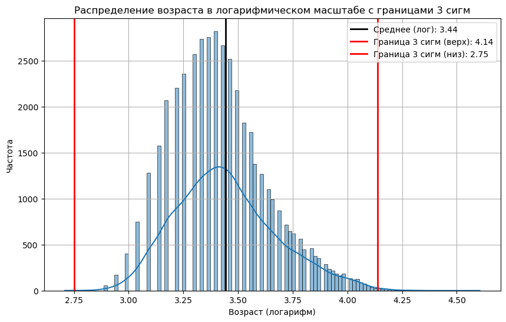

```
31137     15
32950     15
33654    100
Name: Возраст, dtype: int32
```

```python
# ваш код здесь

log_age = np.log(clear_db["Возраст"])

# Построение графика
plt.figure(figsize=(10, 6))
sns.histplot(log_age, kde=True)

# Линия среднего
mean_age = log_age.mean()
plt.axvline(mean_age, color="k", lw=2, label=f"Среднее (лог): {mean_age:.2f}")

# Линии для границ интервала трёх сигм
std_age = log_age.std()
plt.axvline(
    mean_age + 3 * std_age,
    color="r",
    lw=2,
    label=f"Граница 3 сигм (верх): {mean_age + 3 * std_age:.2f}",
)
plt.axvline(
    mean_age - 3 * std_age,
    color="r",
    lw=2,
    label=f"Граница 3 сигм (низ): {mean_age - 3 * std_age:.2f}",
)

plt.title("Распределение возраста в логарифмическом масштабе с границами 3 сигм")
plt.xlabel("Возраст (логарифм)")
plt.ylabel("Частота")
plt.legend()
plt.grid()
plt.show()


# Расчет Z-отклонений
mean_log_age = log_age.mean()
std_log_age = log_age.std()
z_scores = (log_age - mean_log_age) / std_log_age

# Найдем выбросы (в пределах 4 сигм по правую сторону и 3 по левую)
outliers = clear_db[(z_scores > 4) | (z_scores < -3)]

print(outliers["Возраст"])
```

ваш коммментарий здесь

- распределение имеет правостороннюю асиммтерию
- в таблицу выбросов попали люди с возрастом 15 и 100 лет